[figure not shown]

# Assignment E3: Using cartopy for mapping

Name: Mahlatse Motubatse Student number: MTBMAH005

### Assignment Brief:

Write a notebook to produce the following maps

The Antarctic continent and the Southern Ocean starting from 60°S The South Atlantic, from 20°S to 50°S. The map should show the following locations: Walvis Bay, Cape Town, Rio de Janeiro, Montevideo Choose the most appropriate projection and extent. Each map should look professional with the gridlines, the coordinate labels and any other feature you think it would enhance its look. You will be judged mostly on the quality of the figure, because the maps can be created simply by putting together the instructions from the tutorial. If you just use the default settings, you will get a maximum of 12 points.

Upload the commented notebook on your GitHub repository in a new E3 folder and copy the link to the repository in the text window below to complete your submission.

##### ANSWER:

###### 1.

```python
import cartopy.crs as ccrs
import cartopy
import cartopy.feature as cfeature
import matplotlib.pyplot as plt
```

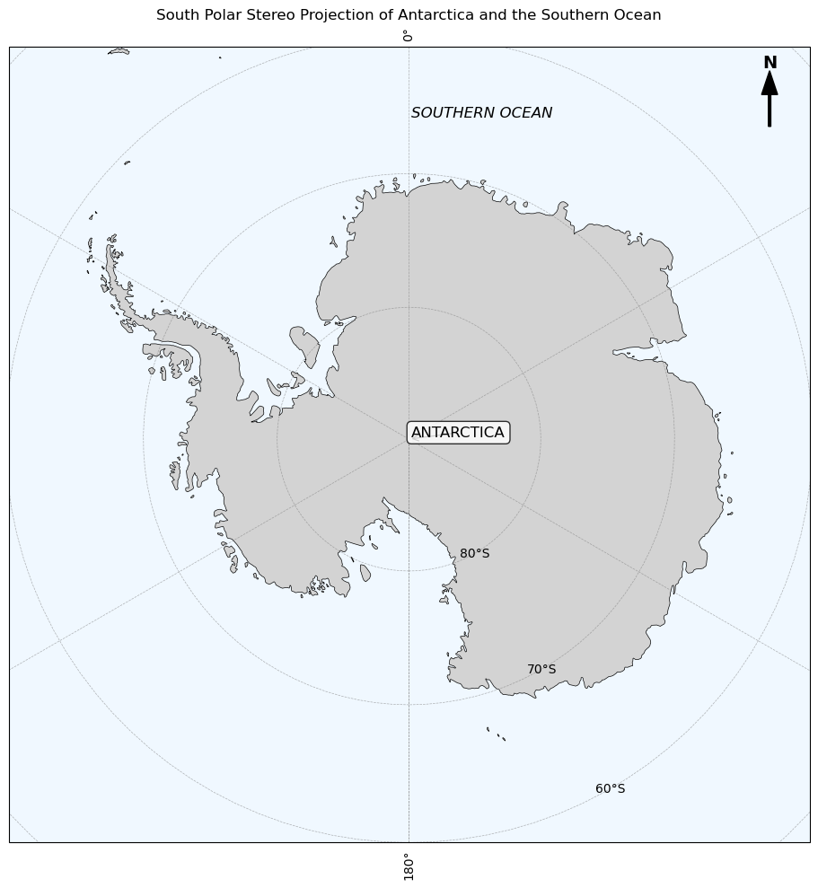

```python
fig = plt.figure(figsize=(10, 10))
ax = plt.axes(projection=ccrs.SouthPolarStereo())

ax.set_extent([-180, 180, -90, -60], crs=ccrs.PlateCarree())

ax.add_feature(cfeature.LAND, facecolor='lightgray')
ax.add_feature(cfeature.OCEAN, facecolor='aliceblue')
ax.add_feature(cfeature.COASTLINE, linewidth=0.5)
ax.add_feature(cfeature.BORDERS, linestyle=':')

gl = ax.gridlines(draw_labels=True,
                  linewidth=0.5,
                  color='gray',
                  alpha=0.6,
                  linestyle='--')

# Here I am annotating over Antarctica.
ax.annotate("ANTARCTICA",
            xy=(0, -90),
            xycoords=ccrs.PlateCarree()._as_mpl_transform(ax),
            xytext=(2, 2),
            textcoords='offset points',
            fontsize=12,
            bbox=dict(boxstyle="round", fc="white", alpha=0.8),
            arrowprops=dict(arrowstyle='->', lw=0.8))

ax.annotate("SOUTHERN OCEAN",
            xy=(0, -66),
            xycoords=ccrs.PlateCarree()._as_mpl_transform(ax),
            xytext=(2, 2),
            textcoords='offset points',
            fontsize=12,
           fontstyle='italic')

ax.text(0.95, 0.98, 'N',
        transform=ax.transAxes,
        fontsize=14,
        fontweight='bold',
        ha='center',
        va='center')

ax.arrow(0.95, 0.90, 0, 0.04,
         transform=ax.transAxes,
         width=0.003,
         head_width=0.02,
         head_length=0.03,
         color='black')

gl.xlabel_style = {'size': 10}
gl.ylabel_style = {'size': 10}

# Title
plt.title("South Polar Stereo Projection of Antarctica and the Southern Ocean",
          fontsize=12)

plt.tight_layout()
plt.show()
```

Figure 1: South Polar Stereo projection of Antarctica and the Southern Ocean.

###### 2.

[figure not shown]

```python
cities = {
    "Walvis Bay": (14.5, -23),
    "Cape Town": (18.4, -34),
    "Rio de Janeiro": (-43.2, -23),
    "Montevideo": (-56.2, -35)
}

fig = plt.figure(figsize=(12, 8))
ax = plt.axes(projection=ccrs.Mercator())

ax.set_extent([-70, 30, -50, -20], crs=ccrs.PlateCarree())

ax.add_feature(cfeature.LAND, facecolor='lightgray')
ax.add_feature(cfeature.OCEAN, facecolor='aliceblue')
ax.add_feature(cfeature.COASTLINE, linewidth=0.8)
cfeature.NaturalEarthFeature('physical', 'land', '110m')

gl = ax.gridlines(draw_labels=True,
                  linewidth=0.6,
                  color='gray',
                  alpha=0.6,
                  linestyle='--')

gl.top_labels = False
gl.right_labels = False
gl.xlabel_style = {'size': 10}
gl.ylabel_style = {'size': 10}

for city, (lon, lat) in cities.items():
    ax.plot(lon, lat,
            marker='*',
            color='black',
            markersize=5,
            transform=ccrs.PlateCarree())

    ax.text(lon + 2, lat,
            city,
            fontsize=9,
            transform=ccrs.PlateCarree())

    ax.text(0.94, 0.78, 'SOUTHERN AFRICA',
        transform=ax.transAxes,
        fontsize=10,
        ha='center',
        va='center')

    ax.text(0.10, 0.80, 'SOUTHERN SOUTH AMERICA',
        transform=ax.transAxes,
        fontsize=10,
        ha='center',
        va='center')

ax.text(0.50, 0.50, 'SOUTH ATLANTIC OCEAN',
        transform=ax.transAxes,
        fontsize=10,
        ha='center',
        va='center',
        color = 'blue')

ax.text(0.95, 0.30, 'N',
        transform=ax.transAxes,
        fontsize=14,
        fontweight='bold',
        ha='center',
        va='center')

ax.arrow(0.95, 0.20, 0, 0.04,
         transform=ax.transAxes,
         width=0.003,
         head_width=0.02,
         head_length=0.03,
         color='black')


plt.title("A classical Mercatorial representation of the South Atlantic Ocean (20°S to 50°S)",
          fontsize=14,
          weight='bold')

plt.tight_layout()
plt.show()
```

Figure 2: Location of Cape Town, Montevideo, Rio de Janeiro and Walvis Bay along the souther African and South American coastlines bordering the South Atlantic Ocean.